# Lab_2

Yoni Potter

1/20/2022

### Loading Packages

Messages and warnings are hidden to avoid unnecessary clutter.

```r
library(sf)
library(terra)
library(spData)
library(spDataLarge)
library(units)
library(RColorBrewer)
```

### Question 1

```r
summary(world["geom"])
```

```
##             geom
##  MULTIPOLYGON :177
##  epsg:4326    :  0
##  +proj=long...:  0
```

The above output tells us that the geometry is of the type `MULTIPOLYGON`, that there are 177 countries, and that it is in the CRS `"EPSG:4326"`.

### Question 2

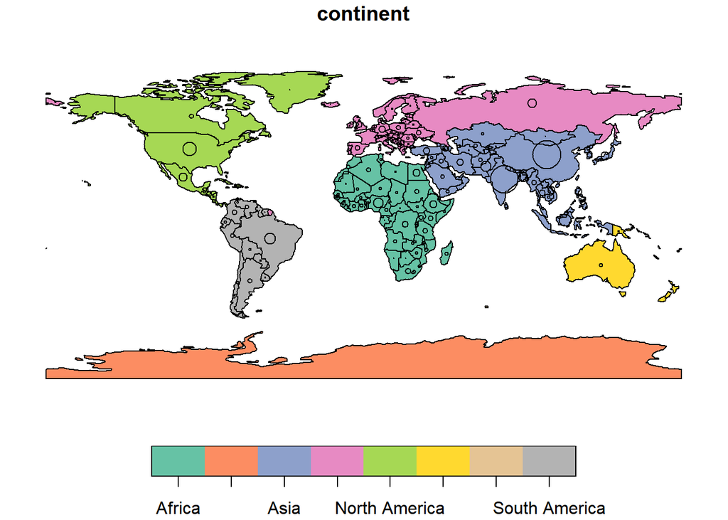

```r
# Plot countries, categorized by continent
plot(world["continent"], reset = FALSE)

# Set the radius of population symbols
cex <- sqrt(world$pop) / 10000

# Create centroids
world_cents <- st_centroid(world, of_largest_polygon = TRUE)
# Add centroids on top of countries
plot(st_geometry(world_cents), add = TRUE, cex = cex)
```

**Two similarities:**

1. Both categorize countries by continent using color
2. Both represent each country’s population by the size of the centroid dots

**Two differences:**

1. The plot in the book includes graticule lines, which can be created with `st_graticule()`
2. The plot in the book projects the continents, centroids, and graticule lines into a different CRS (referred to as `"+proj=eck4"`)

The `cex` argument controls the symbol size. Because the area of a circle is proportional to the square of its radius, and `cex`, I would assume, controls the radius of the symbol, it is important to assign `cex` to a value proportional to the square root of the population, in order for the area to be directly proportional to the population. It was then divided by 10000 because, otherwise, the ciricles would be way too large (as population numbers of countries are high, and graphing units are generally much smaller).

### Question 3

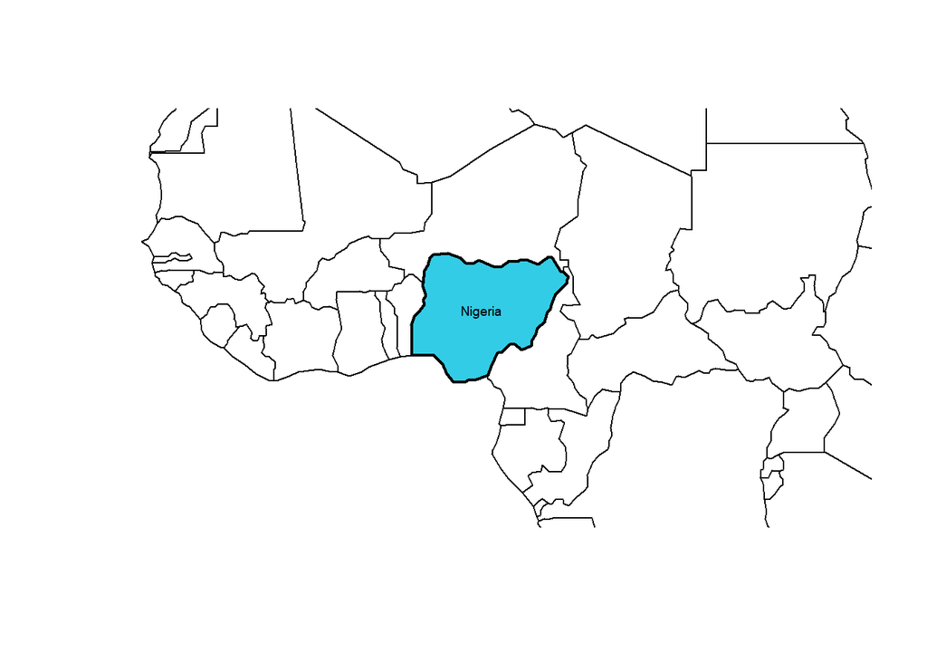

```r
# Create subsets of the world: Nigeria alone and Africa as a whole
nigeria <- world[world$name_long == "Nigeria", ]
africa <- world[world$continent == "Africa", ]

# Plot Nigeria alone
plot(st_geometry(nigeria), expandBB = c(1, 1, 1, 1), lwd = 2, col = rgb(.2, .8, .9, 1), reset = FALSE)

# Add Background with other surrounding countries
plot(africa[0], add = TRUE)

# Add a label
text(8, 9.5, "Nigeria", cex = .6)
```

### Question 4

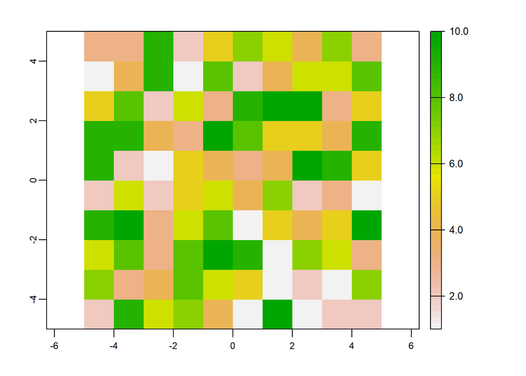

```r
# Create raster
my_raster <- rast(nrows = 10, ncols = 10, resolution = 1,
                   xmin = -5, xmax = 5,
                   ymin = -5, ymax = 5,
                   vals = sample(1:10, 100, replace = TRUE))

# Plot raster
plot(my_raster)
```

### Question 5

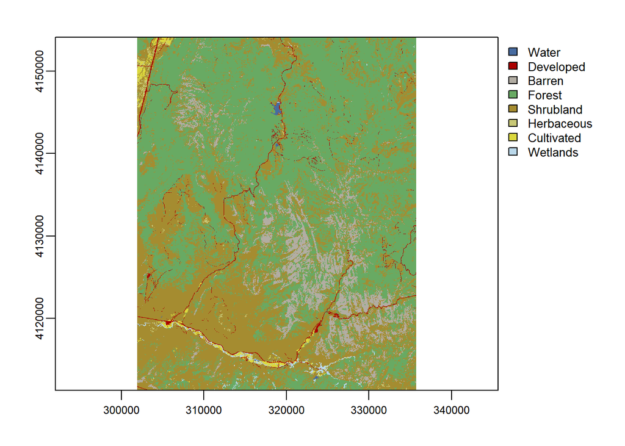

```r
# Load raster file
nlcd <- rast(system.file("raster/nlcd.tif", package = "spDataLarge"))

# Plot (why not?)
plot(nlcd)
```

```r
# Get information
nlcd
```

```
## class       : SpatRaster
## dimensions  : 1359, 1073, 1  (nrow, ncol, nlyr)
## resolution  : 31.5303, 31.52466  (x, y)
## extent      : 301903.3, 335735.4, 4111244, 4154086  (xmin, xmax, ymin, ymax)
## coord. ref. : NAD83 / UTM zone 12N (EPSG:26912)
## source      : nlcd.tif
## name        :   levels
## min value   :   Barren
## max value   : Wetlands
```

By simply typing the name of the object, in this case `nlcd`, we can find:

- The object’s class (the data format)
- Dimensions (number of rows, columns, and layers)
- Resolution (size of each cell)
- Extent (spatial extent of whole raster)
- The CRS (how the data are projected)
- The source (where the file came from)
- The name(s) of the layer(s)
- The minimum and maximum values (in this case, I believe they are ordered alphabetically, as the data are categorical)

### Question 6

```r
# Check CRS
crs(nlcd)
```

```
## [1] "PROJCRS[\"NAD83 / UTM zone 12N\",\n    BASEGEOGCRS[\"NAD83\",\n        DATUM[\"North American Datum 1983\",\n            ELLIPSOID[\"GRS 1980\",6378137,298.257222101,\n                LENGTHUNIT[\"metre\",1]]],\n        PRIMEM[\"Greenwich\",0,\n            ANGLEUNIT[\"degree\",0.017453292519…
```

Though this output is far messier than the output you’d get from `st_crs` on a vector object (I think they forgot to hide escape characters and line breaks!), the information listed includes:

- The datum
- The CRS name
- The projection method
- The units of measurement
- The general area the CRS covers